# Assignment 1

2023-02-15

# Introduction

Cancer is the leading cause of death in Canada (Canadian Cancer Association, n.d.), with 11% of all deaths being attributed to colorectal cancer (Canadian Cancer Association, 2022). In particular, the development of drug resistance in the late stages of colorectal cancer often nullifies the effect of certain treatments (Charitou et al., 2019). As this is found to be a key player in poor survival outcomes, it is imperative that alternative drug targets and therapeutics be identified and formulated.

In the paper “Transcriptional and metabolic rewiring of colorectal cancer cells expressing the oncogenic KRASG13D mutation” (Charitou et al., 2019), the authors identify mutations in the proto-oncogene KRAS as a particularly important factor in cancer progression and the cancer cell’s development of drug resistance. However, as KRAS is currently not a viable therapeutic target, the authors focus on the downstream effects of KRAS and potential therapeutic targets in these altered pathways. One of the genes that are upregulated by KRAS is transforming growth factor alpha (TGF$\alpha$), which has been implicated as a cancer driver in colorectal cancer. Thus, investigation into how TGF$\alpha$ affects the transcriptional landscape of cancer cells may reveal potential drug targets for colorectal cancer.

## Installing Relevant Packages

```r
if(!requireNamespace("knitr", quietly=TRUE))
  install.packages("knitr")

if (! require("BiocManager", quietly=TRUE))
  install.packages("BiocManager")

if(! requireNamespace("edgeR", quietly=TRUE))
  BiocManager::install("edgeR")

if(! requireNamespace("biomaRt", quietly=TRUE))
  BiocManager::install("biomaRt")

if (!requireNamespace("GEOquery", quietly=TRUE))
  BiocManager::install("GEOquery")
```

# Clean the data and map to HUGO symbols

## Downloading the data

```r
fnames <- "GSE105094/GSE105094_RNAseq_Counts_HCT116_HKE3.txt.gz"

# Check if the supplementary file already exists, if not then download it
if (! file.exists(fnames)){
  gse <- GEOquery::getGEO("GSE105094", GSEMatrix=FALSE)
  sfiles = GEOquery::getGEOSuppFiles("GSE105094")
  fnames = rownames(sfiles)
}

# Read the data into R without modifying the column names
colorectal_countdata <- read.delim(fnames[1], header=TRUE, check.names=FALSE, sep="\t")

# Show first five columns and rows of the count data
knitr::kable(colorectal_countdata[1:5, 1:5], format="html")
```

| Gene | HCT116_T0_Rep1 | HCT116_T0_Rep2 | HCT116_T0_Rep3 | HCT116_T15_Rep1 |
| --- | --- | --- | --- | --- |
| ENSG00000000003 | 628 | 1133 | 1092 | 864 |
| ENSG00000000005 | 0 | 0 | 0 | 0 |
| ENSG00000000419 | 642 | 934 | 956 | 734 |
| ENSG00000000457 | 265 | 312 | 329 | 363 |
| ENSG00000000460 | 222 | 304 | 306 | 306 |

## Calculate Summary Statistics

```r
num_samples <- dim(colorectal_countdata)[2] - 1 # How many samples do we have
num_genes <- dim(colorectal_countdata)[1] # How many genes are measured
num_unique_genes <- length(unique(colorectal_countdata$Gene)) # How many unique genes are measured
num_lack_identifier <- sum(is.na(colorectal_countdata$Gene)) # How many rows do not have an identifier
num_non_genes <- sum(! grepl("ENSG", colorectal_countdata$Gene)) # How many rows are not
                                                                 # classified as a human
                                                                 # gene by their Ensembl ID
```

## Filtering the data

```r
# Transform each entry into counts per million
colorectal_cpms <- edgeR::cpm(colorectal_countdata[,2:ncol(colorectal_countdata)])
rownames(colorectal_cpms) <- colorectal_countdata[,1] # Add the Ensembl IDs as rownames

# Filter out genes with low counts per million
keep <- rowSums(colorectal_cpms > 1) >= 3 # Identify rows that have >= 3 entries with greater than 1 cpm
colorectal_count_filtered <- colorectal_countdata[keep,]

knitr::kable(colorectal_count_filtered[1:5, 1:5], format="html")
```

|  | Gene | HCT116_T0_Rep1 | HCT116_T0_Rep2 | HCT116_T0_Rep3 | HCT116_T15_Rep1 |
| --- | --- | --- | --- | --- | --- |
| 1 | ENSG00000000003 | 628 | 1133 | 1092 | 864 |
| 3 | ENSG00000000419 | 642 | 934 | 956 | 734 |
| 4 | ENSG00000000457 | 265 | 312 | 329 | 363 |
| 5 | ENSG00000000460 | 222 | 304 | 306 | 306 |
| 8 | ENSG00000001036 | 1351 | 1678 | 1514 | 1688 |

```r
num_remaining <- dim(colorectal_count_filtered)[1] # How many genes are left after filtration
```

Here, we used the edgeR package to transform each entry in the original dataset into their corresponding counts per million value. This is done for each sample by dividing each read count from the sample by the total number of counts of said sample. This helps us identify the genes are not highly expressed, as they are unlikely to be interesting.

Here, we filtered out 41680 genes. Thus, only 28.2010646% of rows remain.

## Mapping the Data

```r
# Load the Ensembl version from May 2015 and get the human gene Ensembl ID dataset
ensembl <- biomaRt::useMart("ensembl", host="https://may2015.archive.ensembl.org")
ensembl <- biomaRt::useDataset("hsapiens_gene_ensembl", mart=ensembl)
```

```r
# Convert the Ensembl IDs of the filtered dataset to their HUGO gene symbols
colorectal_hgnc_conversions <- biomaRt::getBM(attributes = c("ensembl_gene_id", "hgnc_symbol"),
                             filters = c("ensembl_gene_id"),
                             values = colorectal_count_filtered$Gene,
                             mart = ensembl)
```

```
## Batch submitting query [=======>-----------------------] 25% eta: 7s Batch
## submitting query [===============>---------------] 50% eta: 5s Batch submitting
## query [======================>--------] 75% eta: 3s
```

```r
# Merge the HGNC conversions to the filtered dataset by matching the Ensembl IDs
colorectal_counts_annot <- merge(colorectal_hgnc_conversions,
                               colorectal_count_filtered,
                               by.x=1, by.y=1, all.y=TRUE)

knitr::kable(colorectal_counts_annot[1:5, 1:5], format="html")
```

| ensembl_gene_id | hgnc_symbol | HCT116_T0_Rep1 | HCT116_T0_Rep2 | HCT116_T0_Rep3 |
| --- | --- | --- | --- | --- |
| ENSG00000000003 | TSPAN6 | 628 | 1133 | 1092 |
| ENSG00000000419 | DPM1 | 642 | 934 | 956 |
| ENSG00000000457 | SCYL3 | 265 | 312 | 329 |
| ENSG00000000460 | C1orf112 | 222 | 304 | 306 |
| ENSG00000001036 | FUCA2 | 1351 | 1678 | 1514 |

Using the merged dataset, I then calculated the number of rows with missing HGNC symbols and the number of HGNC symbols which occur more than once in the dataset:

```r
# Calculate number of missing symbols
num_missing_hgnc <- sum(is.na(colorectal_counts_annot$hgnc_symbol))

# Calculate number of duplicated symbols
num_duplicated_hgnc <- sum(sort(table(colorectal_counts_annot$hgnc_symbol),
                                decreasing=TRUE) > 1)
```

Here, we find that there are 46 rows with missing HGNC symbols (0.2809503% of rows) and 9 HGNC symbols with more than one occurrence in the dataset.

For the missing rows with missing values, I ultimately opted to delete them from the dataset since they represented a small subset of the data. This is for the following reasons: first, there were no other gene identifiers in the original file that I could compare the missing HGNC symbols to. Secondly, while in lecture it was specified that we can keep the missing rows in case they are interesting, the assignment specifications noted that all rows should have a unique HGNC symbol. Thus the deletion of rows with missing HGNC was done by the following:

```r
# Get indices of missing symbols
missing_ind <- which(is.na(colorectal_counts_annot$hgnc_symbol))

# Filter out missing symbols
colorectal_counts_annot <- colorectal_counts_annot[-missing_ind,]
```

Next, I found the HGNC symbols with duplicate values in the dataset. These are summarized in the following:

```r
dup_genes <- sort(table(colorectal_counts_annot$hgnc_symbol), decreasing=TRUE)[2:10]
knitr::kable(dup_genes, format="html")
```

| Var1 | Freq |
| --- | --- |
| RNA5-8S5 | 8 |
| CCDC7 | 2 |
| ICOSLG | 2 |
| MATR3 | 2 |
| MIR3687-2 | 2 |
| PAGR1 | 2 |
| SMIM11 | 2 |
| SYT15 | 2 |
| TAF9 | 2 |

As the paper specifically mentions ribosomal RNA, I decided not to discard RNA-8S5. Since rRNA has multiple copies across the genome, it was suggested on BioStars that I concatenate these (benformatics, 2019).

Next, I found the individual Ensembl IDs of the other genes:

```r
duplicates <- colorectal_counts_annot[which(colorectal_counts_annot$hgnc_symbol %in% c("MATR3", "CCDC7", "ICOSLG", "MIR3687-2", "PAGR1", "SMIM11", "SYT15", "TAF9")),]
```

Searching up the individual Ensembl IDs of these genes, it seems that they may be splicing variants of one another. As these are not necessarily the genes of interest from the paper, and a quick Google search has not linked any of them very strongly to colorectal cancer, I discarded all of the other duplicates.

```r
# Get indices of the duplicated values
rRNA_indices <- which(colorectal_counts_annot$hgnc_symbol == "RNA5-8S5")
dup_ind <- c(rRNA_indices, which(colorectal_counts_annot$hgnc_symbol %in%
                                   c("MATR3", "CCDC7", "ICOSLG", "MIR3687-2",
                                     "PAGR1", "SMIM11", "SYT15", "TAF9")))

# Get subset of dataset corresponding to RNA5-8S5
rRNA_subset <- colorectal_counts_annot[rRNA_indices,]

# Create new row to insert
rRNA_row <- cbind(data.frame(ensembl_gene_id = "ENSG00000273730", hgnc_symbol = "RNA5-8S5"),
                  t(data.frame(colSums(rRNA_subset[,c(3:38)]))))
rownames(rRNA_row) <- NULL

# Delete indices of duplicated values and add combined row for RNA5-8S5 to dataset
colorectal_counts_final <- rbind(colorectal_counts_annot[-dup_ind,], rRNA_row)
```

## Cleaning the data

First, I calculated the numerical summaries for each column:

```r
summary(colorectal_counts_final)
```

```
##  ensembl_gene_id    hgnc_symbol        HCT116_T0_Rep1      HCT116_T0_Rep2
##  Length:16304       Length:16304       Min.   :      0.0   Min.   :     0
##  Class :character   Class :character   1st Qu.:     93.0   1st Qu.:    95
##  Mode  :character   Mode  :character   Median :    432.5   Median :   454
##                                        Mean   :   1853.3   Mean   :  1604
##                                        3rd Qu.:   1257.2   3rd Qu.:  1270
##                                        Max.   :1490345.0   Max.   :719429
##  HCT116_T0_Rep3   HCT116_T15_Rep1     HCT116_T15_Rep2   HCT116_T15_Rep3
##  Min.   :     0   Min.   :      0.0   Min.   :      0   Min.   :      0
##  1st Qu.:    89   1st Qu.:    107.8   1st Qu.:     78   1st Qu.:    165
##  Median :   434   Median :    512.0   Median :    371   Median :    800
##  Mean   :  1553   Mean   :   2126.2   Mean   :   1538   Mean   :   2788
##  3rd Qu.:  1225   3rd Qu.:   1508.0   3rd Qu.:   1117   3rd Qu.:   2270
##  Max.   :686488   Max.   :1492001.0   Max.   :1109830   Max.   :1288388
##  HCT116_T30_Rep1   HCT116_T30_Rep2   HCT116_T30_Rep3   HCT116_T60_Rep1
##  Min.   :      0   Min.   :      0   Min.   :      0   Min.   :      0
##  1st Qu.:     79   1st Qu.:     89   1st Qu.:     96   1st Qu.:     88
##  Median :    378   Median :    454   Median :    460   Median :    399
##  Mean   :   1606   Mean   :   2018   Mean   :   1970   Mean   :   1674
##  3rd Qu.:   1114   3rd Qu.:   1337   3rd Qu.:   1348   3rd Qu.:   1165
##  Max.   :1195257   Max.   :1616513   Max.   :1603482   Max.   :1323693
##  HCT116_T60_Rep2   HCT116_T60_Rep3     HCT116_T90_Rep1  HCT116_T90_Rep2
##  Min.   :      0   Min.   :      0.0   Min.   :     0   Min.   :     0.0
##  1st Qu.:    224   1st Qu.:    111.0   1st Qu.:    99   1st Qu.:    88.0
##  Median :   1044   Median :    544.5   Median :   472   Median :   444.5
##  Mean   :   3779   Mean   :   2284.1   Mean   :  1732   Mean   :  1643.5
##  3rd Qu.:   2936   3rd Qu.:   1587.2   3rd Qu.:  1351   3rd Qu.:  1280.0
##  Max.   :2025271   Max.   :1845068.0   Max.   :822649   Max.   :796251.0
##  HCT116_T90_Rep3   HCT116_T120_Rep1 HCT116_T120_Rep2    HCT116_T120_Rep3
##  Min.   :      0   Min.   :     0   Min.   :      0.0   Min.   :     0
##  1st Qu.:     69   1st Qu.:    86   1st Qu.:    156.0   1st Qu.:   105
##  Median :    318   Median :   415   Median :    764.5   Median :   512
##  Mean   :   1323   Mean   :  1413   Mean   :   2705.1   Mean   :  1772
##  3rd Qu.:    915   3rd Qu.:  1151   3rd Qu.:   2171.0   3rd Qu.:  1441
##  Max.   :1013252   Max.   :633744   Max.   :1251381.0   Max.   :806254
##   HKE3_T0_Rep1     HKE3_T0_Rep2     HKE3_T0_Rep3    HKE3_T15_Rep1
##  Min.   :     0   Min.   :     0   Min.   :     0   Min.   :     0
##  1st Qu.:   102   1st Qu.:   128   1st Qu.:   100   1st Qu.:    70
##  Median :   459   Median :   579   Median :   435   Median :   321
##  Mean   :  1516   Mean   :  1819   Mean   :  1426   Mean   :  1036
```

[output cut: 15 more lines]

```
##  Max.   :1620548.0   Max.   :1124225.0   Max.   :1002085   Max.   :1534726
##  HKE3_T90_Rep1    HKE3_T90_Rep2    HKE3_T90_Rep3       HKE3_T120_Rep1
##  Min.   :     0   Min.   :     0   Min.   :      0.0   Min.   :     0.0
##  1st Qu.:    69   1st Qu.:   148   1st Qu.:    137.0   1st Qu.:    66.0
##  Median :   307   Median :   689   Median :    594.5   Median :   306.0
##  Mean   :  1024   Mean   :  2165   Mean   :   2179.7   Mean   :   989.3
##  3rd Qu.:   901   3rd Qu.:  1951   3rd Qu.:   1742.0   3rd Qu.:   885.0
##  Max.   :392827   Max.   :828650   Max.   :1463983.0   Max.   :359419.0
##  HKE3_T120_Rep2   HKE3_T120_Rep3
##  Min.   :     0   Min.   :     0
##  1st Qu.:   141   1st Qu.:   141
##  Median :   645   Median :   652
##  Mean   :  2088   Mean   :  2081
##  3rd Qu.:  1858   3rd Qu.:  1871
##  Max.   :831003   Max.   :772270
```

From the numerical summaries, there are no entries with a value less than zero which may indicate a technical error. Since there is no evidence otherwise of outliers, none are removed.

# Normalize

Normalization is required to minimize unwanted variation in the data (i.e. sources of variation that we are not testing for, such as technical variation and inherent biological variation). Here, we use the Trimmed Mean of M-values (TMM) in order to normalize the data. TMM and Relative Log Expression (RLE) are two methods specialized in normalizing RNAseq data, which I am using. Further, since from lecture the results of the two methods are comparable, I’ve chosen to use TMM.

## Define the Groups

```r
# Separate samples by "_" and keep the first and second indices
samples <- data.frame(lapply(colnames(colorectal_countdata)[2:37],
                             FUN=function(x){unlist(strsplit(x,
                                                             split="_"))[c(1,2)]}))

# Replace the column names of "samples" with the actual column names of the data
colnames(samples) <- colnames(colorectal_countdata)[2:37]
rownames(samples) <- c("cell_type", "time_point")
samples <- data.frame(t(samples)) # Flip the col and row of the dataframe
```

## Applying TMM

```r
# Turn the numerical values of the cleaned data into a matrix
cleaned_data_matrix <- as.matrix(colorectal_counts_final[,3:38])
rownames(cleaned_data_matrix) <- colorectal_counts_final$hgnc_symbol

# Create a DGEList object
d <- edgeR::DGEList(counts=cleaned_data_matrix, group=samples$time_point)
d <- edgeR::calcNormFactors(d) # Calculate the scaling factors for normalization

normalized_counts <- edgeR::cpm(d) # Get counts per million of the scaling factors
```

## Graphical Comparisons

### Boxplot

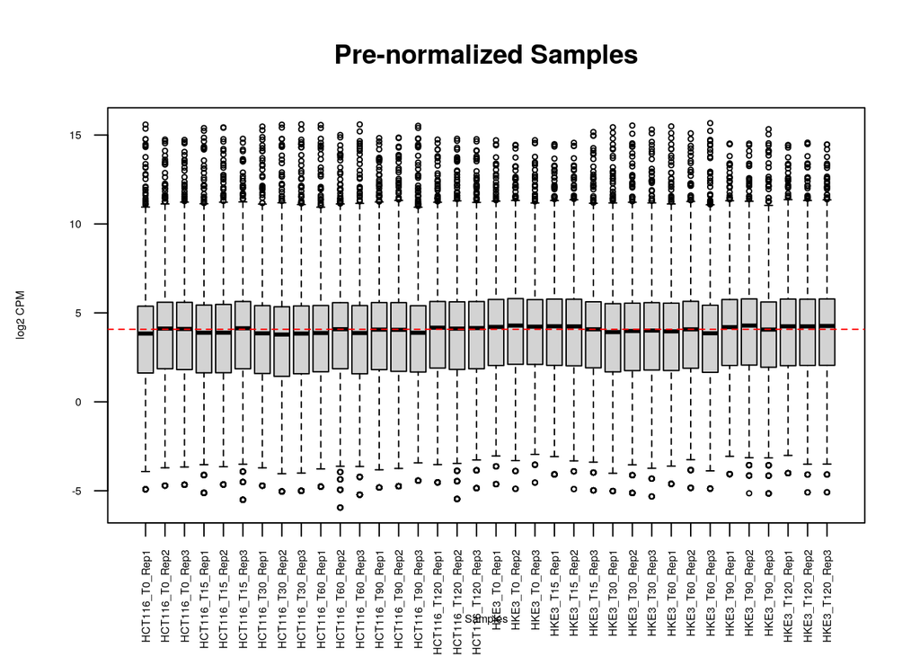

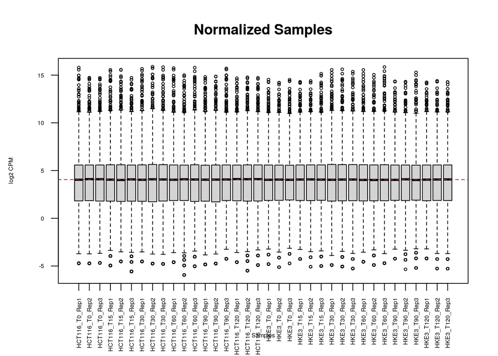

```r
# Get log counts per million of the pre-normalized and normalized counts
prenorm_input <- log2(edgeR::cpm(colorectal_counts_final[,3:38]))
postnorm_input <- log2(normalized_counts)

# Create boxplot of Pre-Normalized Samples
boxplot(prenorm_input, xlab = "Samples", ylab = "log2 CPM",
        las = 2, cex = 0.5, cex.lab = 0.5,
        cex.axis = 0.5,
        main = "Pre-normalized Samples")
# Add median of the sample medians as line
abline(h = median(apply(prenorm_input, 2, median)),
       col = "red", lwd = 1, lty = "dashed")

# Create boxplot of Normalized Samples
boxplot(postnorm_input, xlab = "Samples", ylab = "log2 CPM",
        las = 2, cex = 0.5, cex.lab = 0.5,
        cex.axis = 0.5,
        main = "Normalized Samples")
# Add median of the sample medians as line
abline(h = median(apply(postnorm_input, 2, median)),
       col = "red", lwd = 1, lty = "dashed")
```

**Figure 1.** Comparison of boxplots between pre-normalized and normalized samples.

Comparing the samples before and after normalization, we see that the medians of each sample boxplot are aligned much more closely with the median of the sample medians after normalization as compared to before. This is what we expect, as normalization should result in a reduction of the confounding variability (i.e. due to technical and inherent biological variation) in the data.

### Density Plots

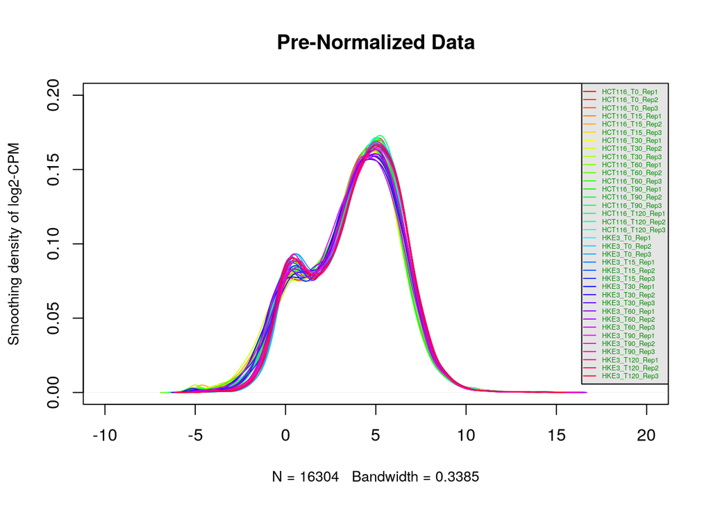

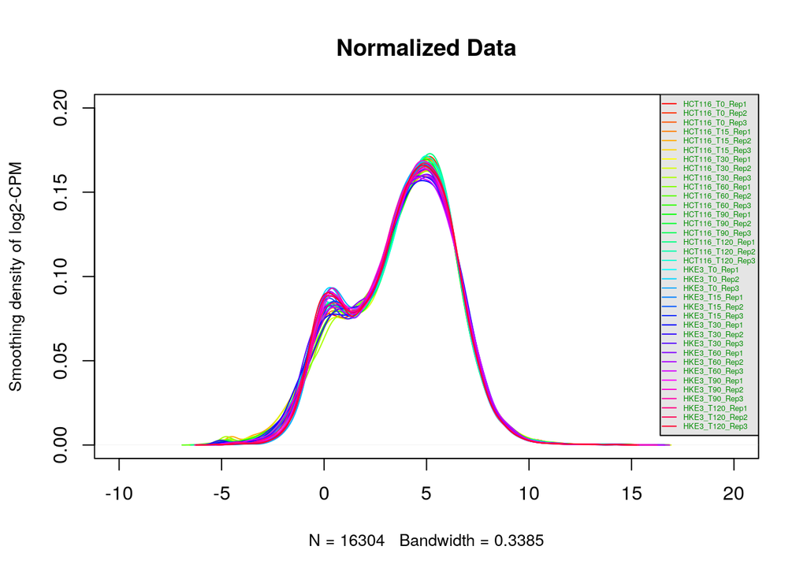

```r
# Calculate the densities of the prenormalization & normalized values
prenorm_counts_density <- apply(prenorm_input, 2, density)
postnorm_counts_density <- apply(postnorm_input, 2, density)

# Create plots
plot_density <- function(df, title){
  xlim <- 0; ylim <- 0
  for(i in 1:length(df)){
    xlim <- range(c(xlim, df[[i]]$x))
    ylim <- range(c(ylim, df[[i]]$y))
  }

  cols <- rainbow(length(df)) # Get color scale
  ltys <- rep(1.5, length(df)) # Set line type

  # Create plot with consistent x and y limits
  plot(df[[1]], xlim=c(-10,20), ylim=c(0, 0.2), type="n",
       ylab="Smoothing density of log2-CPM",
       main=title, cex.lab=0.85)

  # Add each line (i.e. sample) as a different color
  for(i in 1:length(df)){
    lines(df[[i]], col=cols[i], lty = ltys[i])
  }

  # Add legend
  legend("topright", colnames(prenorm_input),
         col=cols, lty=ltys, cex=0.4,
         border="blue", text.col="green4",
         merge=TRUE, bg="gray90")
}

plot_density(prenorm_counts_density, "Pre-Normalized Data")
plot_density(postnorm_counts_density, "Normalized Data")
```

**Figure 2.** Comparison of the density plots of the samples before and after normalization

Similarly, when comparing the density plots of the density plots before and after normalization, the curves of the normalized data seem much more aligned than the pre-normalized data. This indicates a reduction in the variability in the data, as desired.

Thus from the density plots and the boxplots, we can graphically see that the variation in the data has decreased after normalization, as desired.

The final dataset is therefore the following:

```r
knitr::kable(normalized_counts[1:5, 1:5], format="html", row.names=FALSE)
```

| HCT116_T0_Rep1 | HCT116_T0_Rep2 | HCT116_T0_Rep3 | HCT116_T15_Rep1 | HCT116_T15_Rep2 |
| --- | --- | --- | --- | --- |
| 23.92969 | 42.88668 | 42.82236 | 27.956991 | 24.59938 |
| 24.46315 | 35.35407 | 37.48917 | 23.750499 | 18.39492 |
| 10.09772 | 11.80992 | 12.90161 | 11.745819 | 11.22920 |
| 8.45922 | 11.50711 | 11.99967 | 9.901434 | 10.66119 |
| 51.47931 | 63.51619 | 59.37092 | 54.619676 | 52.43207 |

# Citations

benformatics. (2019). Different Ensembl Ids point to the same gene symbol [Online forum post]. Biostars. https://www.biostars.org/p/389804/

Canadian Cancer Society. (n.d.). Cancer statistics at a glance. Canadian Cancer Society. https://cancer.ca/en/research/cancer-statistics/cancer-statistics-at-a-glance

Canadian Cancer Society. (2022). Colorectal cancer statistics. Canadian Cancer Society. https://cancer.ca/en/cancer-information/cancer-types/colorectal/statistics

Charitou, T., Srihari, S., Lynn, M. A., Jarboui, M. A., Fasterius, E., Moldovan, M., Shirasawa, S., Tsunoda, T., Ueffing, M., Xie, J., Xin, J., Wang, X., Proud, C. G., Boldt, K., Al-Khalili Szigyarto, C., Kolch, W., & Lynn, D. J. (2019). Transcriptional and metabolic rewiring of colorectal cancer cells expressing the oncogenic KRASG13D mutation. British journal of cancer, 121(1), 37–50. https://doi.org/10.1038/s41416-019-0477-7